# Applied Predictive Modeling–Chapter 2 Short Tour

```r
library(data.table)
library(magrittr)
library(ggplot2)
library(caret)
library(earth)
library(AppliedPredictiveModeling)
library(RregressPkg)
library(RplotterPkg)
```

Author: Rick Dean

Article date: 2021-01-15

Abstract

The following notes/scripts/plots are inspired by Chapter 2 of [Applied Predictive Modeling](http://appliedpredictivemodeling.com/) by Max Kuhn and Kjell Johnson.

Note: Look in the “chapters” directory of the AppliedPredictiveModeling package for the R scripts used in the book.

## 2.1 Case Study: Predicting Fuel Economy

Task: Prepare data for plotting.

```r
data(FuelEconomy, package = "AppliedPredictiveModeling")
cars2010_dt <- data.table::setDT(cars2010)
cars2011_dt <- data.table::setDT(cars2011)
str(cars2010_dt)
```

```
## Classes 'data.table' and 'data.frame':   1107 obs. of  14 variables:
##  $ EngDispl           : num  4.7 4.7 4.2 4.2 5.2 5.2 2 6 3 3 ...
##  $ NumCyl             : int  8 8 8 8 10 10 4 12 6 6 ...
##  $ Transmission       : Factor w/ 16 levels "Other","A4","A5",..: 6 11 11 6 6 11 14 14 14 11 ...
##  $ FE                 : num  28 25.6 26.8 25 24.8 ...
##  $ AirAspirationMethod: Factor w/ 3 levels "NaturallyAspirated",..: 1 1 1 1 1 1 3 3 1 1 ...
##  $ NumGears           : int  6 6 6 6 6 6 6 6 6 6 ...
##  $ TransLockup        : num  1 1 1 1 0 0 0 0 1 0 ...
##  $ TransCreeperGear   : num  0 0 0 0 0 0 0 0 0 0 ...
##  $ DriveDesc          : Factor w/ 5 levels "AllWheelDrive",..: 5 5 1 1 1 1 1 1 5 5 ...
##  $ IntakeValvePerCyl  : int  2 2 2 2 2 2 2 2 2 2 ...
##  $ ExhaustValvesPerCyl: int  2 2 2 2 2 2 2 2 2 2 ...
##  $ CarlineClassDesc   : Factor w/ 17 levels "Other","2Seaters",..: 2 2 2 2 2 2 2 2 2 2 ...
##  $ VarValveTiming     : num  1 1 1 1 1 1 1 1 1 1 ...
##  $ VarValveLift       : num  0 0 0 0 0 0 0 0 1 1 ...
##  - attr(*, ".internal.selfref")=<externalptr>
```

2. Select variables and sort by engine displacement:

```r
cars2010_dt <-  cars2010_dt[,year := "2010"] %>%
  .[order(-EngDispl),] %>%
  .[,.(EngDispl, FE, year)]

cars2011_dt <-  cars2011_dt[,year := "2011"] %>%
  .[order(-EngDispl),] %>%
  .[,.(EngDispl, FE, year)]
```

3. Combine data into one data frame:

```r
cars_2010_2011_dt <- data.table::rbindlist(list(cars2010_dt, cars2011_dt))
```

Task: Plot both years of data using `RplotterPkg::multi_scatter_plot()`

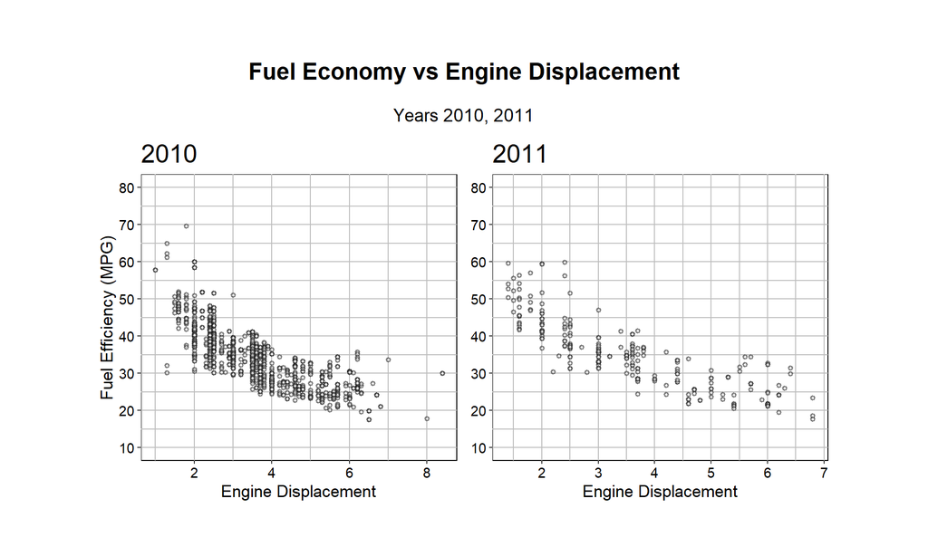

```r
cars_plot <- RplotterPkg::multi_scatter_plot(
  df = cars_2010_2011_dt,
  factor_var = "year",
  factor_x = "EngDispl",
  aes_y = "FE",
  title = "Fuel Economy vs Engine Displacement",
  subtitle = "Years 2010, 2011",
  x_title = "Engine Displacement",
  y_titles = c("Fuel Efficiency (MPG)", NULL),
  y_limits = c(10,80),
  y_major_breaks = seq(10,80,10),
  rot_y_tic_label = TRUE,
  pts_line_alpha = .5
)
```

Task: Fit a single linear model to *cars2010_df* data and conduct 10-fold CV to estimate the error. Plot the fitted line over the observed data.

“10-fold CV” – Split up the training data into 10 segments to compute cross validation (CV) of the model

1. Estimate the linear model:

```r
set.seed(1)
lm1_fit <- caret::train(
  FE ~ EngDispl,
  data = cars2010_dt,
  method = "lm",
  trControl = caret::trainControl(method = "cv")
)
lm1_fit
```

```
## Linear Regression
##
## 1107 samples
##    1 predictor
##
## No pre-processing
## Resampling: Cross-Validated (10 fold)
## Summary of sample sizes: 997, 996, 996, 996, 997, 996, ...
## Resampling results:
##
##   RMSE      Rsquared   MAE
##   4.599148  0.6276266  3.516626
##
## Tuning parameter 'intercept' was held constant at a value of TRUE
```

2. Show a summary of the model:

```r
#str(lm1_fit)
summary(lm1_fit)
```

```
##
## Call:
## lm(formula = .outcome ~ ., data = dat)
##
## Residuals:
##     Min      1Q  Median      3Q     Max
## -14.486  -3.192  -0.365   2.671  27.215
##
## Coefficients:
##             Estimate Std. Error t value Pr(>|t|)
## (Intercept)  50.5632     0.3985  126.89   <2e-16 ***
## EngDispl     -4.5209     0.1065  -42.46   <2e-16 ***
## ---
## Signif. codes:  0 '***' 0.001 '**' 0.01 '*' 0.05 '.' 0.1 ' ' 1
##
## Residual standard error: 4.624 on 1105 degrees of freedom
## Multiple R-squared:   0.62,  Adjusted R-squared:  0.6196
## F-statistic:  1803 on 1 and 1105 DF,  p-value: < 2.2e-16
```

3. Add the predicted values computed from the lm1_fit model to *cars2010_dt*:

```r
cars2010_dt[,lm1_fit := stats::predict(lm1_fit)]
```

4. Plot the linear fit *lm1_fit* line through the observed data:

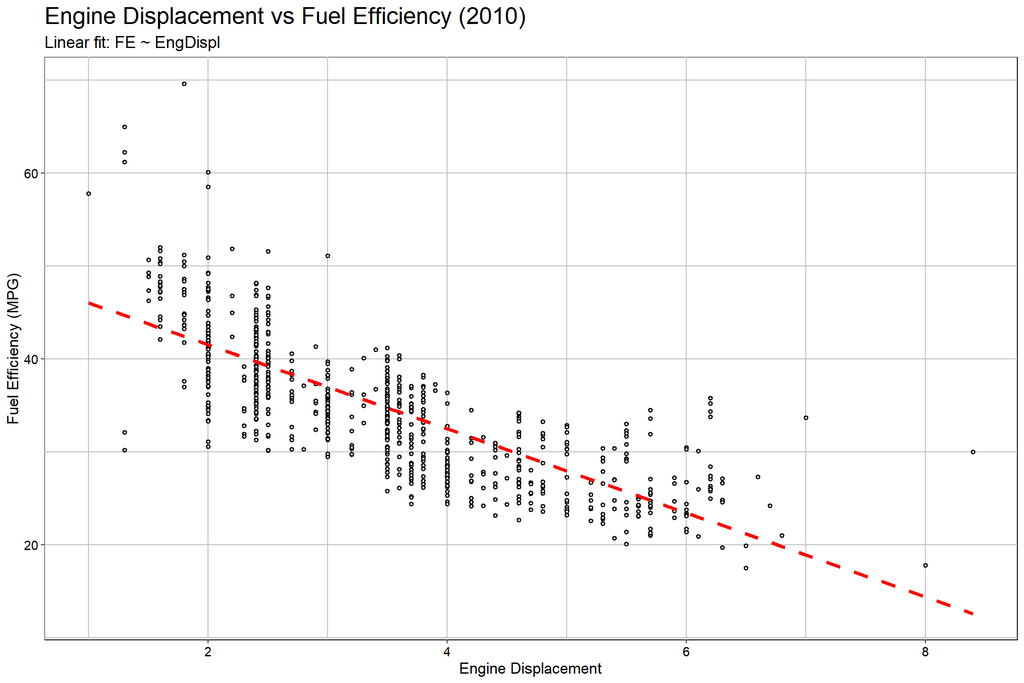

```r
RplotterPkg::create_scatter_plot(
  df = cars2010_dt,
  aes_x = "EngDispl",
  aes_y = "FE",
  title = "Engine Displacement vs Fuel Efficiency (2010)",
  subtitle = "Linear fit: FE ~ EngDispl",
  x_title = "Engine Displacement",
  y_title = "Fuel Efficiency (MPG)",
  rot_y_tic_label = TRUE
) +
  geom_line(aes(y = lm1_fit), color = "red", linetype = 2, size = 1.5)
```

5. Plot the observed versus the fitted response values:

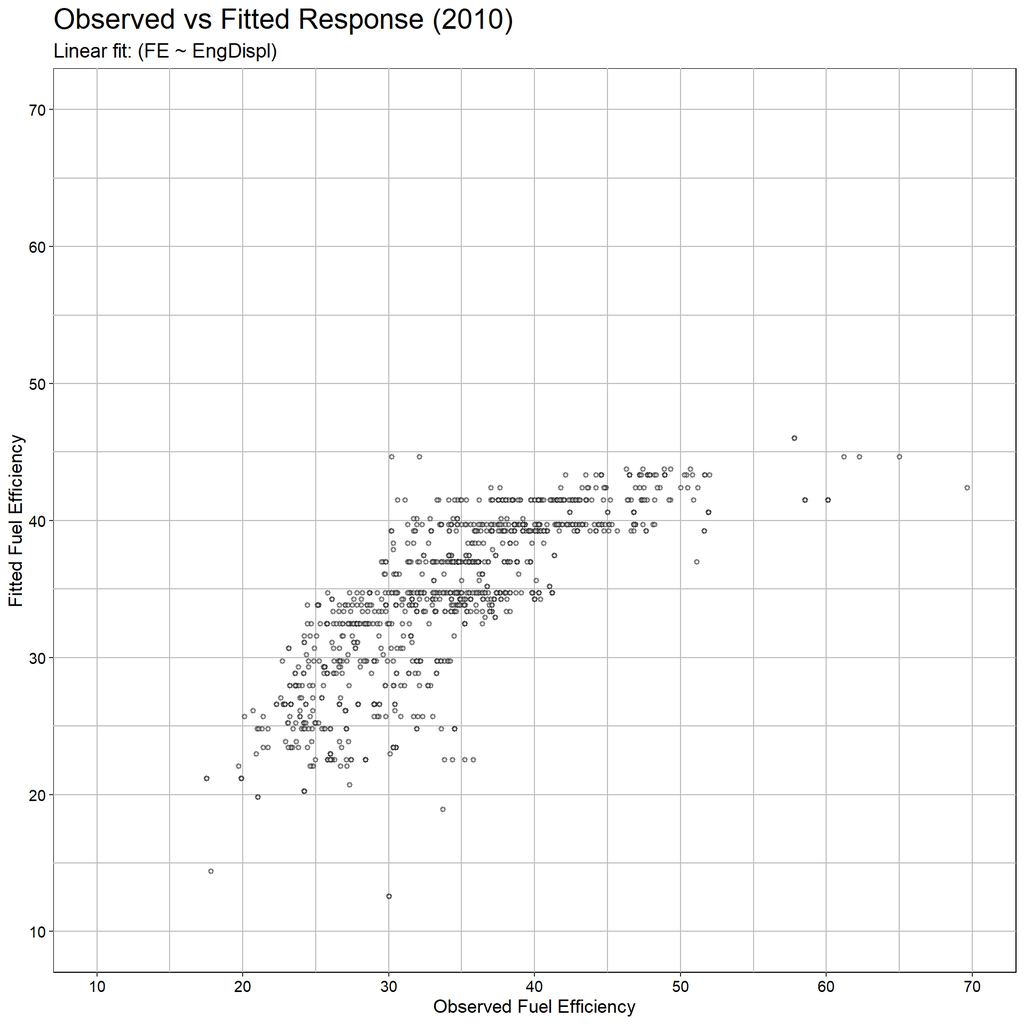

```r
df <- data.frame(
  Observed = cars2010_dt$FE,
  Fitted = lm1_fit$finalModel$fitted.values
)
RplotterPkg::create_scatter_plot(
  df = df,
  aes_x = "Observed",
  aes_y = "Fitted",
  title = "Observed vs Fitted Response (2010)",
  subtitle = "Linear fit: (FE ~ EngDispl)",
  x_title = "Observed Fuel Efficiency",
  y_title = "Fitted Fuel Efficiency",
  rot_y_tic_label = T,
  pts_line_alpha = 0.5,
  x_limits = c(10, 70),
  x_major_breaks = seq(10,70,10),
  y_limits = c(10, 70),
  y_major_breaks = seq(10,70,10)
)
```

Task: Add a quadratic term to the model and plot the fitted curve over the observed data.

1. Add the squared term to cars2010_dt:

```r
cars2010_dt[, EngDispl2 := EngDispl^2]
```

2. Estimate the quadratic model:

```r
lm2_fit <- caret::train(
  FE ~ EngDispl + EngDispl2,
  data = cars2010_dt,
  method = "lm",
  trControl = caret::trainControl(method = "cv")
)
lm2_fit
```

```
## Linear Regression
##
## 1107 samples
##    2 predictor
##
## No pre-processing
## Resampling: Cross-Validated (10 fold)
## Summary of sample sizes: 997, 997, 996, 996, 996, 995, ...
## Resampling results:
##
##   RMSE      Rsquared   MAE
##   4.224937  0.6847105  3.233939
##
## Tuning parameter 'intercept' was held constant at a value of TRUE
```

The squared term reduces the RMSE from 4.6 to 4.2.

3. Show a summary of the model:

```r
summary(lm2_fit)
```

```
##
## Call:
## lm(formula = .outcome ~ ., data = dat)
##
## Residuals:
##      Min       1Q   Median       3Q      Max
## -19.1862  -2.5977  -0.3028   2.6089  24.7385
##
## Coefficients:
##              Estimate Std. Error t value Pr(>|t|)
## (Intercept)  63.23343    0.94761   66.73   <2e-16 ***
## EngDispl    -11.86738    0.51627  -22.99   <2e-16 ***
## EngDispl2     0.93510    0.06453   14.49   <2e-16 ***
## ---
## Signif. codes:  0 '***' 0.001 '**' 0.01 '*' 0.05 '.' 0.1 ' ' 1
##
## Residual standard error: 4.241 on 1104 degrees of freedom
## Multiple R-squared:  0.6807, Adjusted R-squared:  0.6801
## F-statistic:  1177 on 2 and 1104 DF,  p-value: < 2.2e-16
```

4. Add the predicted values computed from the model to *cars2010_dt*:

```r
cars2010_dt[,lm2_fit := stats::predict(lm2_fit)]
```

5. Plot the quadratic fit *lm2_fit* line through the observed data:

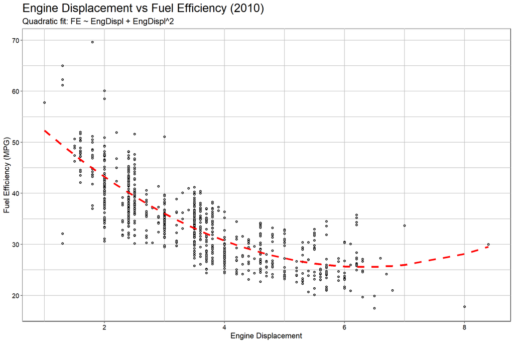

```r
RplotterPkg::create_scatter_plot(
  df = cars2010_dt,
  aes_x = "EngDispl",
  aes_y = "FE",
  title = "Engine Displacement vs Fuel Efficiency (2010)",
  subtitle = "Quadratic fit: FE ~ EngDispl + EngDispl^2",
  x_title = "Engine Displacement",
  y_title = "Fuel Efficiency (MPG)",
  rot_y_tic_label = TRUE
) +
  geom_line(aes(y = lm2_fit), color = "red", linetype = 2, size = 1.5)
```

6. Plot the observed versus the fitted response values:

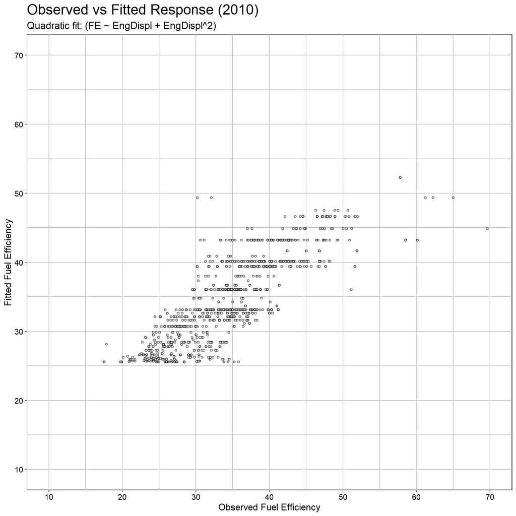

```r
df <- data.frame(
  Observed = cars2010_dt$FE,
  Fitted = lm2_fit$finalModel$fitted.values
)
RplotterPkg::create_scatter_plot(
  df = df,
  aes_x = "Observed",
  aes_y = "Fitted",
  title = "Observed vs Fitted Response (2010)",
  subtitle = "Quadratic fit: (FE ~ EngDispl + EngDispl^2)",
  x_title = "Observed Fuel Efficiency",
  y_title = "Fitted Fuel Efficiency",
  rot_y_tic_label = TRUE,
  pts_line_alpha = 0.5,
  x_limits = c(10, 70),
  x_major_breaks = seq(10,70,10),
  y_limits = c(10, 70),
  y_major_breaks = seq(10,70,10)
)
```

Task: Fit a multivariate adaptive regression spline (MARS) model to *cars2010_dt* data. Plot the fitted curve over the observed data.

1. Estimate the MARS model:

```r
set.seed(1)
mars_fit <- train(
  FE ~ EngDispl,
  data = cars2010_dt,
  method = "earth",
  tuneLength = 15,
  trControl = trainControl(method= "cv"))
mars_fit
```

```
## Multivariate Adaptive Regression Spline
##
## 1107 samples
##    1 predictor
##
## No pre-processing
## Resampling: Cross-Validated (10 fold)
## Summary of sample sizes: 997, 996, 996, 996, 997, 996, ...
## Resampling results across tuning parameters:
##
##   nprune  RMSE      Rsquared   MAE
##   2       4.296800  0.6724542  3.311010
##   3       4.257025  0.6790729  3.270311
##   4       4.205443  0.6854161  3.210850
##   5       4.219783  0.6830568  3.210954
##
## Tuning parameter 'degree' was held constant at a value of 1
## RMSE was used to select the optimal model using the smallest value.
## The final values used for the model were nprune = 4 and degree = 1.
```

Selecting 4 terms with RMSE: 4.21; Rsquared: 0.69 – about the same as the quadratic model.

2. Show a summary of the model:

```r
summary(mars_fit)
```

```
## Call: earth(x=c(8.4,8.4,8,7,6...), y=c(30,30,17.8,33...), keepxy=TRUE,
##             degree=1, nprune=4)
##
##                 coefficients
## (Intercept)        19.670414
## h(EngDispl-2.3)     4.473552
## h(4.3-EngDispl)    10.289593
## h(EngDispl-4.3)    -5.936361
##
## Selected 4 of 5 terms, and 1 of 1 predictors (nprune=4)
## Termination condition: RSq changed by less than 0.001 at 5 terms
## Importance: EngDispl
## Number of terms at each degree of interaction: 1 3 (additive model)
## GCV 18.03665    RSS 19714.85    GRSq 0.67947    RSq 0.6829383
```

3. Add the predicted values computed from the model to *cars2010_dt*:

```r
cars2010_dt[,mars_fit := stats::predict(mars_fit)]
```

4. Plot the MARS fit *mars_fit* line through the observed data:

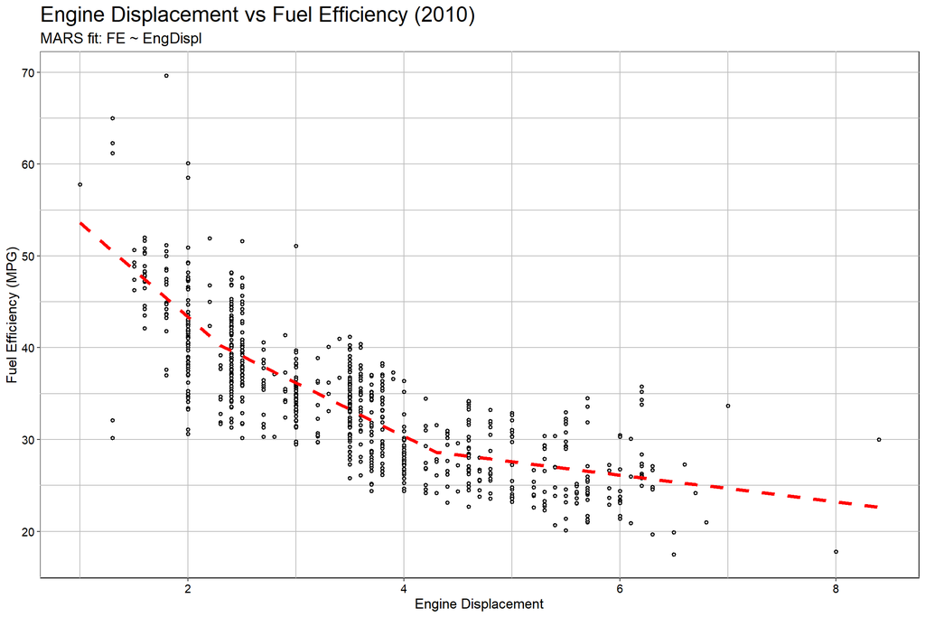

```r
RplotterPkg::create_scatter_plot(
  df = cars2010_dt,
  aes_x = "EngDispl",
  aes_y = "FE",
  title = "Engine Displacement vs Fuel Efficiency (2010)",
  subtitle = "MARS fit: FE ~ EngDispl",
  x_title = "Engine Displacement",
  y_title = "Fuel Efficiency (MPG)",
  rot_y_tic_label = TRUE
) +
  geom_line(aes(y = mars_fit), color = "red", linetype = 2, size = 1.5)
```

5. Plot the observed versus the fitted response values:

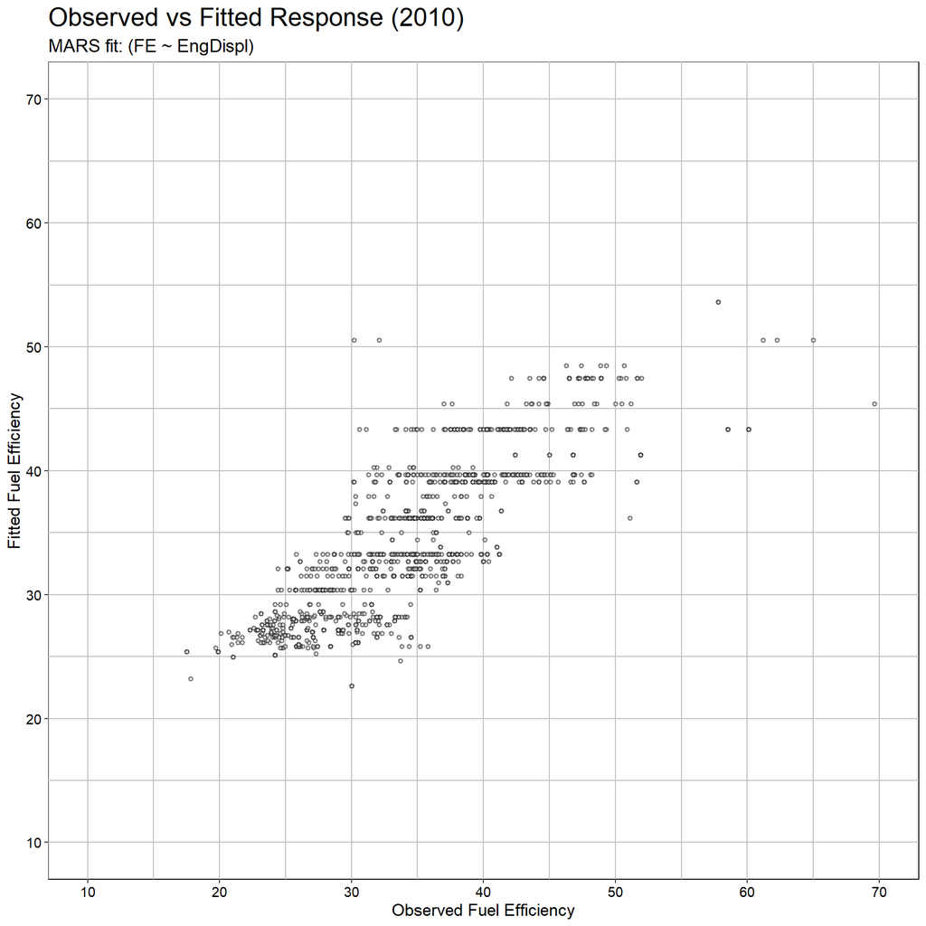

```r
df <- data.frame(
  Observed = cars2010_dt$FE,
  Fitted = mars_fit$finalModel$fitted.values[,1]
)
RplotterPkg::create_scatter_plot(
  df = df,
  aes_x = "Observed",
  aes_y = "Fitted",
  title = "Observed vs Fitted Response (2010)",
  subtitle = "MARS fit: (FE ~ EngDispl)",
  x_title = "Observed Fuel Efficiency",
  y_title = "Fitted Fuel Efficiency",
  rot_y_tic_label = TRUE,
  pts_line_alpha = 0.5,
  x_limits = c(10, 70),
  x_major_breaks = seq(10,70,10),
  y_limits = c(10, 70),
  y_major_breaks = seq(10,70,10)
)
```

Task: Apply the quadratic and MARS models to the 2011 test data.

1. Compute the predictions for the quadratic lm2_fit model:

```r
cars2011_dt[, EngDispl2 := EngDispl^2] %>%
  .[, lm2_fit := stats::predict(lm2_fit, cars2011_dt)] %>%
  .[, mars_fit := stats::predict(mars_fit, cars2011_dt)]
```

2. Plot the predictions for the test set *cars2011_dt*:

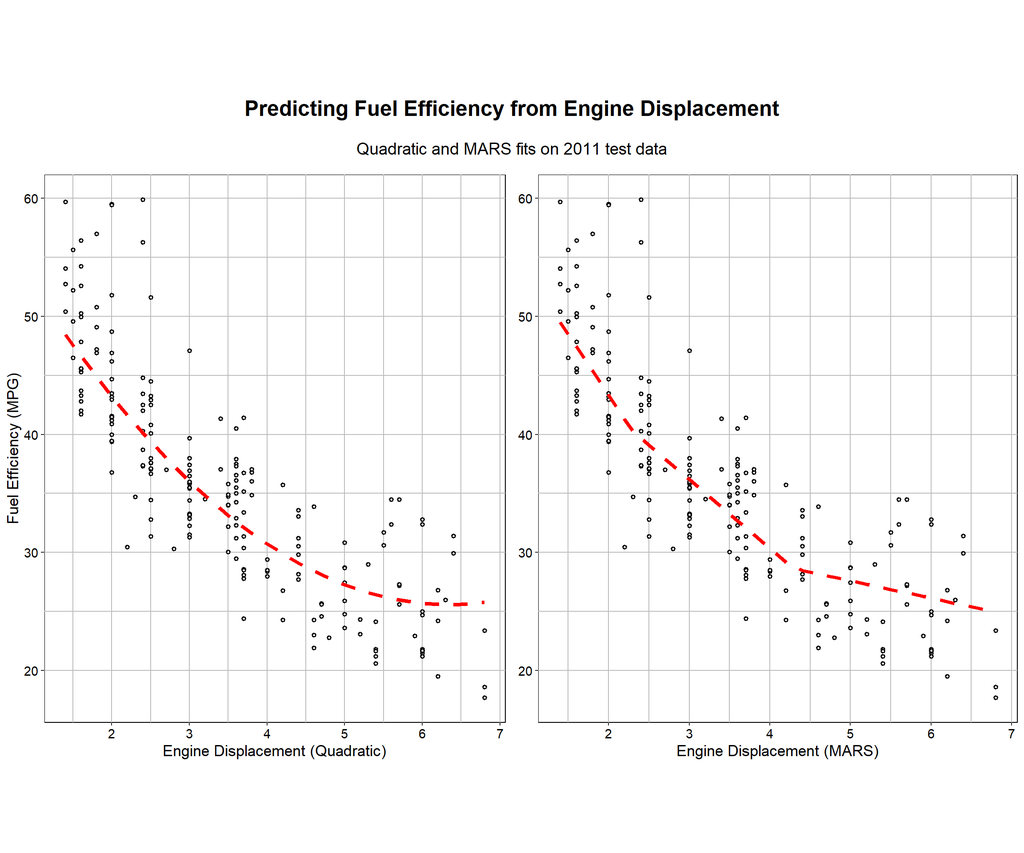

```r
lm2_fit_plot <- RplotterPkg::create_scatter_plot(
  df = cars2011_dt,
  aes_x = "EngDispl",
  aes_y = "FE",
  x_title = "Engine Displacement (Quadratic)",
  y_title = "Fuel Efficiency (MPG)",
  rot_y_tic_label = TRUE
)+
  geom_line(aes(y = lm2_fit), color = "red", linetype = 2, size = 1.5)

mars_fit_plot <- RplotterPkg::create_scatter_plot(
  df = cars2011_dt,
  aes_x = "EngDispl",
  aes_y = "FE",
  x_title = "Engine Displacement (MARS)",
  do_y_title = FALSE,
  rot_y_tic_label = TRUE
) +
  geom_line(aes(y = mars_fit), color = "red", linetype = 2, size = 1.5)

layout <- list(
  plots = list(lm2_fit_plot, mars_fit_plot),
  rows = c(1,1),
  cols = c(1,2)
)

lm2_mars_plot <- RplotterPkg::multi_panel_grid(
  layout = layout,
  col_widths = c(6,6),
  row_heights = 7,
  title = "Predicting Fuel Efficiency from Engine Displacement",
  subtitle = "Quadratic and MARS fits on 2011 test data"
)
```

Task: Get the MARS test set performance values via caret’s postResample function.

```r
mars_performance <- caret::postResample(pred = cars2011_dt$mars_fit, obs = cars2011_dt$FE)
```

[output not shown]